# SPAM Detection with ML Algorithms

Aybike Dilek

19/12/2020

# Objective

The objective of this project is to build a CART model to detect spam emails using UCI Spambase data.

# Preprocessing

The dataset is imported as spambase_csv and it is examined with the glimpse.The *class* column is examined in detail. Then, the dataset is split into train and test set. **%25** is test and **75%** for the train.

```r
spambase_csv <- read_csv("C:/Users/Aybike/Desktop/spambase_csv.csv")

glimpse(spambase_csv)
```

```
## Rows: 4,601
## Columns: 58
## $ word_freq_make             <dbl> 0.00, 0.21, 0.06, 0.00, 0.00, 0.00, 0.00...
## $ word_freq_address          <dbl> 0.64, 0.28, 0.00, 0.00, 0.00, 0.00, 0.00...
## $ word_freq_all              <dbl> 0.64, 0.50, 0.71, 0.00, 0.00, 0.00, 0.00...
## $ word_freq_3d               <dbl> 0, 0, 0, 0, 0, 0, 0, 0, 0, 0, 0, 0, 0, 0...
## $ word_freq_our              <dbl> 0.32, 0.14, 1.23, 0.63, 0.63, 1.85, 1.92...
## $ word_freq_over             <dbl> 0.00, 0.28, 0.19, 0.00, 0.00, 0.00, 0.00...
## $ word_freq_remove           <dbl> 0.00, 0.21, 0.19, 0.31, 0.31, 0.00, 0.00...
## $ word_freq_internet         <dbl> 0.00, 0.07, 0.12, 0.63, 0.63, 1.85, 0.00...
## $ word_freq_order            <dbl> 0.00, 0.00, 0.64, 0.31, 0.31, 0.00, 0.00...
## $ word_freq_mail             <dbl> 0.00, 0.94, 0.25, 0.63, 0.63, 0.00, 0.64...
## $ word_freq_receive          <dbl> 0.00, 0.21, 0.38, 0.31, 0.31, 0.00, 0.96...
## $ word_freq_will             <dbl> 0.64, 0.79, 0.45, 0.31, 0.31, 0.00, 1.28...
## $ word_freq_people           <dbl> 0.00, 0.65, 0.12, 0.31, 0.31, 0.00, 0.00...
```

[output cut: 45 more lines]

```r
summary(spambase_csv$class)
```

```
##    Min. 1st Qu.  Median    Mean 3rd Qu.    Max.
##   0.000   0.000   0.000   0.394   1.000   1.000
```

```r
set.seed(58) #set seed to obtain the same sample in each run of the model.
spambase_csv = spambase_csv %>% filter(complete.cases(.)) %>%
  mutate(train_test = ifelse(runif(nrow(.)) < 0.25,"test","train"))

spam_train <- spambase_csv %>% filter(train_test == "train") %>% select(-train_test)

spam_test <- spambase_csv %>% filter(train_test=="test") %>% select(-train_test)
```

# CART Modelling

The R package **rpart** is used for building a model to predict that, an e-mail is a spam or ham. The output of the model (y) is either 1 or 0, therefore the method=“class” argument is used in the rpart model.

```r
fit <- rpart(class ~ .,
             method="class", data=spam_train)
```

The Classification Tree of the train set is plotted with **rpart.plot**.

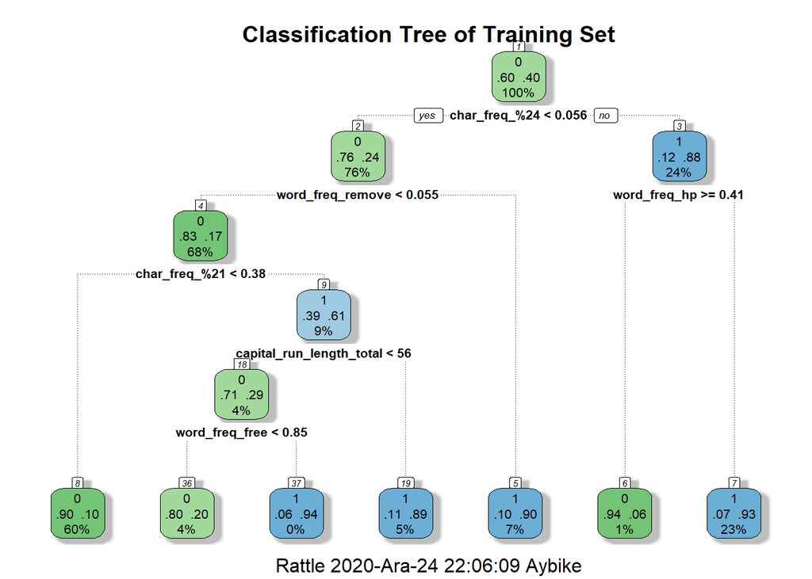

```r
fancyRpartPlot(fit,main = "Classification Tree of Training Set\n")
```

First, the data is split in two: fewer char_freq_%24 (less than 0.056 char_freq_%24, to the left of the tree) and more char_freq_%24 (more than 0.056 char_freq_%24, to the right). The left group makes up **76%** of the original sample, versus **24%** for the other one. As an example, the explanation of Node 7 is if char_freq_%24 is greater than or equal to 0.056 and word_freq_hp is less than 0.41, then the probability of being spam (1) is **0.93**.

# CART Analysis

After fitting the model, it is run with the train and the test set.

## In Sample Analysis

Firstly, the model is run with the train set. The prediction values are obtained. The probability outputs are changed using if-else statements. Then the data is grouped according to the accuracy as TRUE-FALSE. Finally, it is summarized as the count and percentage of accuracy.

```r
spam_predict_in_sample <- as_tibble(predict(fit))
names(spam_predict_in_sample)[1] <- "Ham"
names(spam_predict_in_sample)[2] <- "Spam"

print(head(spam_predict_in_sample))
```

```
## # A tibble: 6 x 2
##      Ham  Spam
##    <dbl> <dbl>
## 1 0.114  0.886
## 2 0.0657 0.934
## 3 0.0992 0.901
## 4 0.0992 0.901
## 5 0.897  0.103
## 6 0.897  0.103
```

```r
in_sample_prediction <-
  cbind(
    spam_predict_in_sample %>%
      transmute(spam_predict = ifelse(Spam >= 0.5,1,0)),
    spam_train %>%
      transmute(spam_actual = ifelse(class == 1,1,0))
  ) %>%
  mutate(correct_class = (spam_predict == spam_actual)) %>%
  group_by(correct_class) %>%
  summarise(count=n(),percentage=round(n()/nrow(.),4))

print(in_sample_prediction)
```

```
## # A tibble: 2 x 3
##   correct_class count percentage
##   <lgl>         <int>      <dbl>
## 1 FALSE           335     0.0977
## 2 TRUE           3094     0.902
```

The in sample accuracy of the model is obtained as **90,2%**.

## Out of Sample Analysis

In this part, the model is run with the test set. The same procedures are applied as In Sample Analysis.

```r
spam_predict_in_test_set <- as_tibble(predict(fit,newdata=spam_test))
names(spam_predict_in_test_set)[1] <- "Ham"
names(spam_predict_in_test_set)[2] <- "Spam"

print(spam_predict_in_test_set)
```

```
## # A tibble: 1,172 x 2
##       Ham  Spam
##     <dbl> <dbl>
##  1 0.0657 0.934
##  2 0.897  0.103
##  3 0.0992 0.901
##  4 0.0657 0.934
##  5 0.0657 0.934
##  6 0.114  0.886
##  7 0.0657 0.934
##  8 0.0992 0.901
##  9 0.0625 0.938
## 10 0.114  0.886
## # ... with 1,162 more rows
```

```r
out_of_sample_prediction <-
  cbind(
    spam_predict_in_test_set%>%
      transmute(spam_predict = ifelse(Spam >= 0.5,1,0)),
    spam_test %>%
      transmute(spam_actual = ifelse(class == 1,1,0))
  ) %>%
  mutate(correct_class = (spam_predict == spam_actual)) %>%
  group_by(correct_class) %>%
  summarise(count=n(),percentage=round(n()/nrow(.),4))

print(out_of_sample_prediction)
```

```
## # A tibble: 2 x 3
##   correct_class count percentage
##   <lgl>         <int>      <dbl>
## 1 FALSE           113     0.0964
## 2 TRUE           1059     0.904
```

The out of sample accuracy of the model is obtained as **90,4%**.

# Logistic Regression Modelling

Logistic regression is a algorithm, which is used to predict a binary outcome based on a set of independent variables. In this model, the binary outcome is **class** and independent variables are the remaining columns.

Logit and Probit are the two links type of the logistic regression model. They were built using **glm**.

- Logit could be used when the data have a *standard logistic distribution of errors*.
- Probit could be used when the data have a *normal distribution of errors*.

[For additional information about the Logit and Probit](https://liberalarts.utexas.edu/prc/_files/cs/Fall2013_Moore_Logistic_Probit_Regression.pdf)

```r
spam_logit_model <- glm(class ~ ., data=spam_train,family=binomial(link = "logit"))
spam_probit_model <- glm(class ~ ., data=spam_train,family=binomial(link = "probit"))
```

In Sample and Out of Sample analysis are done for both Logistic Regression models respectively.

## Logit-Logistic Regression Analysis

```r
spam_logit_in_sample <- predict(spam_logit_model,type="response")

spam_logit_in_sample_prediction <-
  data.frame(in_sample=(spam_logit_in_sample >= 0.5)*1,
             actual=(spam_train$class == 1)*1) %>%
  mutate(correct_class= (in_sample == actual)) %>%
  group_by(correct_class) %>%
  summarise(count=n(),percentage=round(n()/nrow(.),4))


print(spam_logit_in_sample_prediction)
```

```
## # A tibble: 2 x 3
##   correct_class count percentage
##   <lgl>         <int>      <dbl>
## 1 FALSE           249     0.0726
## 2 TRUE           3180     0.927
```

```r
spam_logit_out_of_sample <- predict(spam_logit_model,newdata=spam_test,type="response")

spam_logit_out_of_sample_prediction <-
  data.frame(out_of_sample=(spam_logit_out_of_sample >= 0.5)*1,
             actual=(spam_test$class == 1)*1) %>%
  mutate(correct_class= (out_of_sample == actual)) %>%
  group_by(correct_class) %>%
  summarise(count=n(),percentage=round(n()/nrow(.),4))

print(spam_logit_out_of_sample_prediction)
```

```
## # A tibble: 2 x 3
##   correct_class count percentage
##   <lgl>         <int>      <dbl>
## 1 FALSE            81     0.0691
## 2 TRUE           1091     0.931
```

## Probit-Logistic Regression Analysis

```r
spam_probit_in_sample <- predict(spam_probit_model,type="response")

spam_probit_in_sample_prediction <-
  data.frame(in_sample=(spam_probit_in_sample >= 0.5)*1,
             actual=(spam_train$class == 1)*1) %>%
  mutate(correct_class= (in_sample == actual)) %>%
  group_by(correct_class) %>%
  summarise(count=n(),percentage=round(n()/nrow(.),4))


print(spam_probit_in_sample_prediction)
```

```
## # A tibble: 2 x 3
##   correct_class count percentage
##   <lgl>         <int>      <dbl>
## 1 FALSE           400      0.117
## 2 TRUE           3029      0.883
```

```r
spam_probit_out_of_sample <- predict(spam_probit_model,newdata=spam_test,type="response")

spam_probit_out_of_sample_prediction <-
  data.frame(out_of_sample=(spam_probit_out_of_sample >= 0.5)*1,
             actual=(spam_test$class == 1)*1) %>%
  mutate(correct_class= (out_of_sample == actual)) %>%
  group_by(correct_class) %>%
  summarise(count=n(),percentage=n()/nrow(.))


print(spam_probit_out_of_sample_prediction)
```

```
## # A tibble: 2 x 3
##   correct_class count percentage
##   <lgl>         <int>      <dbl>
## 1 FALSE           128      0.109
## 2 TRUE           1044      0.891
```

# Comparison of Models

The outputs of the three models are shown together.

```r
complete_benchmark <- data.frame(
  model = c("CART","Logistic Reg. - Logit","Logistic Reg. - Probit"),
  in_sample_accuracy = c(
    in_sample_prediction %>% filter(correct_class) %>% transmute(round(percentage,4)) %>% unlist(),
    spam_logit_in_sample_prediction %>% filter(correct_class) %>% transmute(round(percentage,4)) %>% unlist(),
    spam_probit_in_sample_prediction %>% filter(correct_class) %>% transmute(round(percentage,4)) %>% unlist()
  ),
  out_of_sample_accuracy = c(
    out_of_sample_prediction %>% filter(correct_class) %>% transmute(round(percentage,4)) %>% unlist(),
    spam_logit_out_of_sample_prediction %>% filter(correct_class) %>% transmute(round(percentage,4)) %>% unlist(),
    spam_probit_out_of_sample_prediction %>% filter(correct_class) %>% transmute(round(percentage,4)) %>% unlist()
  )

)

print(complete_benchmark)
```

```
##                    model in_sample_accuracy out_of_sample_accuracy
## 1                   CART             0.9023                 0.9036
## 2  Logistic Reg. - Logit             0.9274                 0.9309
## 3 Logistic Reg. - Probit             0.8833                 0.8908
```

As a result, **Logistic Reg. - Logit** model has the highest model accuracy in both in_sample and out_of_sample respectively **92,74%**, **93,09%**.

# References

- [Data Source - UCI Database Portal](http://archive.ics.uci.edu/ml/machine-learning-databases/spambase/)
- [Classification & Regression Trees](http://www.di.fc.ul.pt/~jpn/r/tree/tree.html)
- [Statistical Models in R: Part 2](https://mef-bda503.github.io/archive/fall17/files/intro_to_ml_2.html)
- [Decision trees and extensions](http://www.gcoqueret.com/files/S5_Trees.nb.html#14_variable_importance)
- [What is Logistic Regression?](https://careerfoundry.com/en/blog/data-analytics/what-is-logistic-regression/#2-what-is-logistic-regression)

*You may click* [here](https://pjournal.github.io/mef04-AybikeDilek/) *to reach other items of my progress journal.*